# Listening to Online Reviews — L’Occitane & La Mer

## 2. Review Length Analysis

The assignment asks us to examine whether longer reviews express more positive sentiments. We first characterize review length, define thresholds for “long” and “short,” then test sentiment differences statistically.

```r
reviews <- reviews %>%
  mutate(review_length = nchar(review_text))

mean_length   <- round(mean(reviews$review_length, na.rm = TRUE), 1)
median_length <- median(reviews$review_length, na.rm = TRUE)
p75_length    <- quantile(reviews$review_length, 0.75, na.rm = TRUE)
p25_length    <- quantile(reviews$review_length, 0.25, na.rm = TRUE)

cat("Mean review length (chars):   ", mean_length, "\n")
```

```
## Mean review length (chars):    404.1
```

```r
cat("Median review length (chars): ", median_length, "\n")
```

```
## Median review length (chars):  327
```

```r
cat("25th percentile:              ", p25_length, "\n")
```

```
## 25th percentile:               219.75
```

```r
cat("75th percentile:              ", p75_length, "\n")
```

```
## 75th percentile:               505.5
```

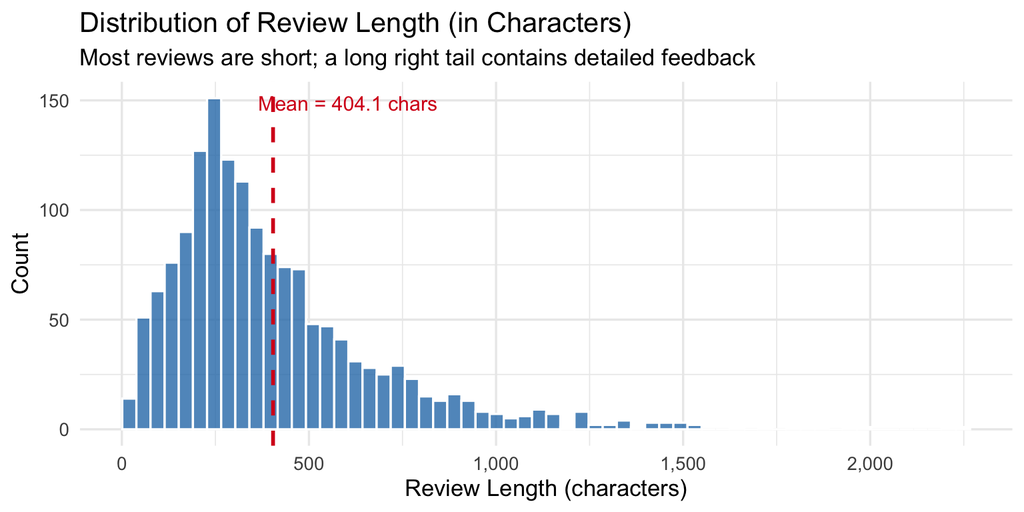

```r
ggplot(reviews, aes(x = review_length)) +
  geom_histogram(bins = 60, fill = "#2c7bb6", alpha = 0.8, color = "white") +
  geom_vline(xintercept = mean_length, color = "#d7191c", linetype = "dashed", linewidth = 1) +
  annotate("text", x = mean_length + 200, y = Inf, vjust = 2,
           label = paste0("Mean = ", mean_length, " chars"), color = "#d7191c", size = 4) +
  scale_x_continuous(labels = comma) +
  labs(
    title    = "Distribution of Review Length (in Characters)",
    subtitle = "Most reviews are short; a long right tail contains detailed feedback",
    x        = "Review Length (characters)",
    y        = "Count"
  ) +
  theme_minimal(base_size = 13)
```

**Thresholds for long vs. short reviews:** - **Short review:** below the 25th percentile (< 219.75 characters) - **Long review:** above the 75th percentile (> 505.5 characters)

This percentile-based definition is data-driven and avoids arbitrary cutoffs. The mean of 404.1 characters is pulled upward by a small number of extremely long reviews.

```r
reviews <- reviews %>%
  mutate(length_cat = case_when(
    review_length < p25_length ~ "Short",
    review_length > p75_length ~ "Long",
    TRUE                       ~ "Medium"
  ))

table(reviews$length_cat)
```

```
##
##   Long Medium  Short
##    384    768    384
```

## 3. VADER Sentiment Analysis

VADER (Valence Aware Dictionary and sEntiment Reasoner) is a lexicon-based sentiment tool designed for social media and review text. It outputs four scores per text: positive, negative, neutral, and a compound score ranging from -1 (most negative) to +1 (most positive).

```r
# Note: This loop takes ~2–10 minutes depending on dataset size.
# Results are cached after the first run.
vader_results <- vader_df(reviews$review_text)

reviews <- reviews %>%
  bind_cols(vader_results %>% select(compound, pos, neg, neu))
```

### 3a. VADER Scores by Star Rating (All 5 Stars)

```r
vader_star <- reviews %>%
  group_by(rating) %>%
  summarise(
    n             = n(),
    avg_compound  = round(mean(compound, na.rm = TRUE), 4),
    avg_positive  = round(mean(pos,      na.rm = TRUE), 4),
    avg_negative  = round(mean(neg,      na.rm = TRUE), 4),
    avg_neutral   = round(mean(neu,      na.rm = TRUE), 4)
  )

vader_star %>%
  kable(caption = "Average VADER Scores by Star Rating (1–5 Stars)") %>%
  kable_styling(bootstrap_options = c("striped", "hover"), full_width = FALSE) %>%
  column_spec(3, bold = TRUE)
```

Average VADER Scores by Star Rating (1–5 Stars)

| rating | n | avg_compound | avg_positive | avg_negative | avg_neutral |
| --- | --- | --- | --- | --- | --- |
| 1 | 167 | 0.1761 | 0.1025 | 0.0783 | 0.8193 |
| 2 | 118 | 0.4707 | 0.1281 | 0.0521 | 0.8198 |
| 3 | 122 | 0.5517 | 0.1372 | 0.0511 | 0.8117 |
| 4 | 211 | 0.7528 | 0.1754 | 0.0314 | 0.7933 |
| 5 | 918 | 0.7585 | 0.1896 | 0.0271 | 0.7833 |

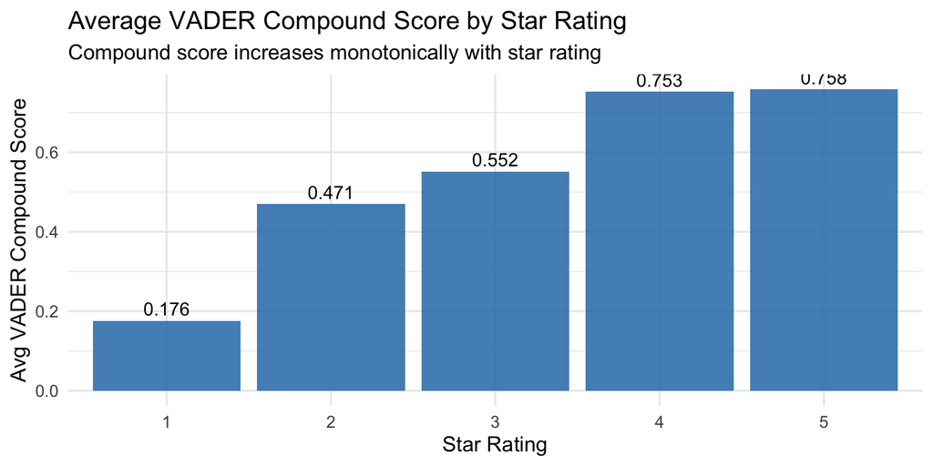

```r
vader_star %>%
  ggplot(aes(x = factor(rating), y = avg_compound)) +
  geom_col(fill = "#2c7bb6", alpha = 0.85) +
  geom_text(aes(label = round(avg_compound, 3)), vjust = -0.4, size = 4) +
  labs(
    title    = "Average VADER Compound Score by Star Rating",
    subtitle = "Compound score increases monotonically with star rating",
    x        = "Star Rating",
    y        = "Avg VADER Compound Score"
  ) +
  theme_minimal(base_size = 13)
```

**Interpretation:** VADER compound scores increase monotonically from 1-star (most negative) to 5-star (most positive), validating that the sentiment lexicon is capturing meaningful signal in these beauty reviews. This monotonic pattern is an important sanity check: if VADER scores did not track star ratings, it would suggest the tool was failing to parse domain-specific language.